# Floats, Figures, and Tables

Published

September 22, 2024

## 1 Figures

To add a figure, use the following basic syntax:

```
![caption](img/image-path.png){#fig-scientific-universe}
```

For example,

```
![The scale of the universe mapped to the branches of science and the hierarchy
    of science. CC BY-SA 3.0 (2013) [Wikimedia Commons](https://en.wikipedia.org/wiki/Science#/media/File:The_Scientific_Universe.png).
    ](img/1024px-the-scientific-universe.png){#fig-scientific-universe}
```

produces:

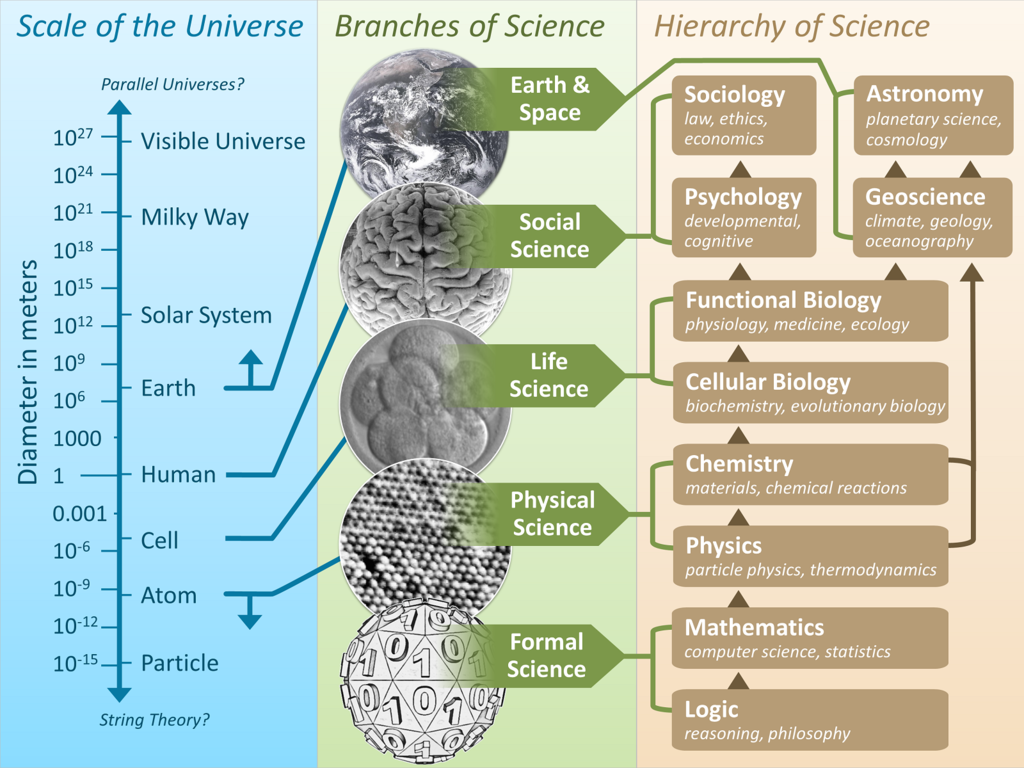

Figure 1: The scale of the universe mapped to the branches of science and the hierarchy of science. CC BY-SA 3.0 (2013) [Wikimedia Commons](https://en.wikipedia.org/wiki/Science#/media/File:The_Scientific_Universe.png).

Figure 1 shows some cool things.

Another example:

```
![The observed (solid) local $p_{0}$ as a function of $m_{H}$ in the low mass range.
    The dashed curve shows the expected local $p_{0}$ under the hypothesis of a
    SM Higgs boson signal at that mass with its $\pm{}1\sigma$ band.
    The horizontal dashed lines indicate the $p$-values corresponding to significances
    of 1 to 6$\sigma$\ [@ATLAS_2012_Observation_of_a_new_particle_in_the_search]\.
    ](img/ATLAS-local-p0-vs-mH.png){#fig-ATLAS-local-p0-vs-mH}
```

produces:

[figure not shown]

Figure 2: The observed (solid) local $p_{0}$ as a function of $m_{H}$ in the low mass range. The dashed curve shows the expected local $p_{0}$ under the hypothesis of a SM Higgs boson signal at that mass with its $\pm{}1\sigma$ band. The horizontal dashed lines indicate the $p$-values corresponding to significances of 1 to 6$\sigma$ (ATLAS Collaboration, 2012).

You can refer to labeled figuers like this:

```
[@fig-ATLAS-local-p0-vs-mH] shows the $p_{0}$ value as a function of the reconstructed
Higgs mass from the ATLAS experiment.
```

Figure 2 shows the $p_{0}$ value as a function of the reconstructed Higgs mass from the ATLAS experiment.